# CCMU Personnes âgées SMUR

Pronostic à 6 mois

Philippe MICHEL

2021-01-06

# Description des données

L’échantillon comporte 260 cas pour 17 variables dont deux calculées.

Les CCMU “D” ont été notées en donnée absente, les “P” en CCMU1.

|  | <76 ans (N=197) | > 75 ans (N=63) | Overall (N=260) |
| --- | --- | --- | --- |
| sexe |  |  |  |
| F | 81 (41.1%) | 38 (60.3%) | 119 (45.8%) |
| M | 116 (58.9%) | 25 (39.7%) | 141 (54.2%) |
| ccmu |  |  |  |
| 1 | 10 (5.1%) | 2 (3.2%) | 12 (4.6%) |
| 2 | 89 (45.2%) | 18 (28.6%) | 107 (41.2%) |
| 3 | 61 (31.0%) | 23 (36.5%) | 84 (32.3%) |
| 4 | 16 (8.1%) | 13 (20.6%) | 29 (11.2%) |
| 5 | 20 (10.2%) | 6 (9.5%) | 26 (10.0%) |
| Missing | 1 (0.5%) | 1 (1.6%) | 2 (0.8%) |
| asa_initial |  |  |  |
| I | 50 (25.4%) | 1 (1.6%) | 51 (19.6%) |
| II | 90 (45.7%) | 20 (31.7%) | 110 (42.3%) |
| III | 40 (20.3%) | 23 (36.5%) | 63 (24.2%) |
| IV | 14 (7.1%) | 16 (25.4%) | 30 (11.5%) |
| V | 0 (0%) | 2 (3.2%) | 2 (0.8%) |
| Missing | 3 (1.5%) | 1 (1.6%) | 4 (1.5%) |
| asa_3_mois |  |  |  |
| I | 21 (10.7%) | 0 (0%) | 21 (8.1%) |
| II | 44 (22.3%) | 9 (14.3%) | 53 (20.4%) |
| III | 34 (17.3%) | 18 (28.6%) | 52 (20.0%) |
| IV | 2 (1.0%) | 2 (3.2%) | 4 (1.5%) |
| Missing | 96 (48.7%) | 34 (54.0%) | 130 (50.0%) |
| aggravation_asa |  |  |  |
| non | 78 (39.6%) | 25 (39.7%) | 103 (39.6%) |
| oui | 20 (10.2%) | 4 (6.3%) | 24 (9.2%) |
| Missing | 99 (50.3%) | 34 (54.0%) | 133 (51.2%) |
| adl_initial |  |  |  |
| non dépendant avant | 167 (84.8%) | 28 (44.4%) | 195 (75.0%) |
| Dépendant avant | 23 (11.7%) | 33 (52.4%) | 56 (21.5%) |
| Missing | 7 (3.6%) | 2 (3.2%) | 9 (3.5%) |
| adl_3_mois |  |  |  |
| non dépendant à 3 mois | 82 (41.6%) | 15 (23.8%) | 97 (37.3%) |
| Dépendant à 3 mois | 18 (9.1%) | 14 (22.2%) | 32 (12.3%) |
| Missing | 97 (49.2%) | 34 (54.0%) | 131 (50.4%) |
| aggravation_adl |  |  |  |
| non | 93 (47.2%) | 24 (38.1%) | 117 (45.0%) |
| oui | 7 (3.6%) | 5 (7.9%) | 12 (4.6%) |
| Missing | 97 (49.2%) | 34 (54.0%) | 131 (50.4%) |
| duree_hospitalisation |  |  |  |
| Mean (SD) | 9.03 (18.6) | 14.0 (15.7) | 10.2 (18.0) |
| Median [Min, Max] | 3.00 [0, 90.0] | 5.00 [0, 49.0] | 3.00 [0, 90.0] |
| Missing | 94 (47.7%) | 33 (52.4%) | 127 (48.8%) |
| deces |  |  |  |
| vivant | 101 (51.3%) | 28 (44.4%) | 129 (49.6%) |
| décédé | 24 (12.2%) | 16 (25.4%) | 40 (15.4%) |
| Missing | 72 (36.5%) | 19 (30.2%) | 91 (35.0%) |
| limitation |  |  |  |
| non | 107 (54.3%) | 30 (47.6%) | 137 (52.7%) |
| oui | 19 (9.6%) | 16 (25.4%) | 35 (13.5%) |
| Missing | 71 (36.0%) | 17 (27.0%) | 88 (33.8%) |
| lieu_de_vie_3_mois |  |  |  |
| décédé | 24 (12.2%) | 16 (25.4%) | 40 (15.4%) |
| domicile | 89 (45.2%) | 21 (33.3%) | 110 (42.3%) |
| famille | 1 (0.5%) | 1 (1.6%) | 2 (0.8%) |
| foyer | 1 (0.5%) | 1 (1.6%) | 2 (0.8%) |
| hopital | 0 (0%) | 1 (1.6%) | 1 (0.4%) |
| SSR/EHPAD | 8 (4.1%) | 5 (7.9%) | 13 (5.0%) |
| Missing | 74 (37.6%) | 18 (28.6%) | 92 (35.4%) |

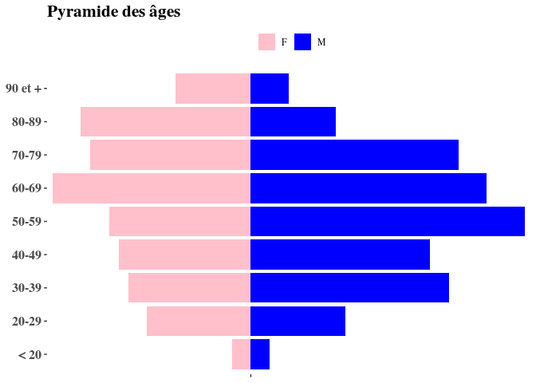

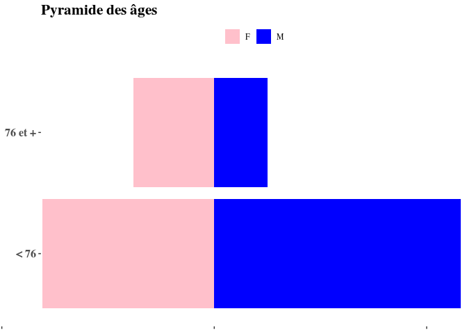

## Analyse factorielle

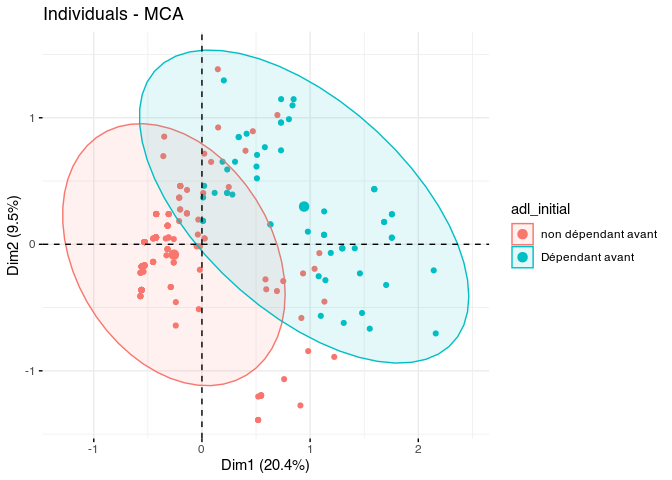

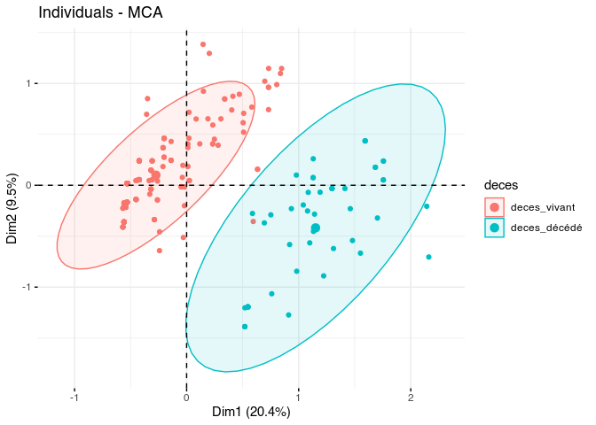

# Comparaisons

On compare les deux groupes selon l’âge avec un seuil à 75 ans.

### Analyse simple

Tableau comparatif

|  | vivant | décédé | p |
| --- | --- | --- | --- |
| sexe |  |  | 0.058 |
| *F* | 64/129 (50 %) [41 ; 59] | 13/40 (32 %) [18 ; 49] |  |
| *M* | 65/129 (50 %) [41 ; 59] | 27/40 (68 %) [51 ; 82] |  |
| age |  |  | 0.021 |
| *<76 ans* | 101/129 (78 %) [70 ; 85] | 24/40 (60 %) [43 ; 76] |  |
| *> 75 ans* | 28/129 (22 %) [15 ; 30] | 16/40 (40 %) [24 ; 57] |  |
| ccmu |  |  | p < 0,001 |
| *1* | 6/129 (4.7 %) [1.5 ; 9.5] | 0/38 (0 %) [NaN ; 7.3] |  |
| *2* | 53/129 (41 %) [32 ; 50] | 5/38 (13 %) [3.7 ; 27] |  |
| *3* | 53/129 (41 %) [32 ; 50] | 5/38 (13 %) [3.7 ; 27] |  |
| *4* | 12/129 (9.3 %) [4.6 ; 15] | 8/38 (21 %) [8.8 ; 37] |  |
| *5* | 5/129 (3.9 %) [1 ; 8.4] | 20/38 (53 %) [36 ; 69] |  |
| asa_initial |  |  | 0.006 |
| *I* | 30/129 (23 %) [16 ; 31] | 5/40 (12 %) [3.5 ; 26] |  |
| *II* | 56/129 (43 %) [35 ; 52] | 11/40 (28 %) [14 ; 44] |  |
| *III* | 29/129 (22 %) [15 ; 30] | 13/40 (32 %) [18 ; 49] |  |
| *IV* | 14/129 (11 %) [5.8 ; 17] | 9/40 (22 %) [10 ; 38] |  |
| *V* | 0/129 (0 %) [NaN ; 2.2] | 2/40 (5 %) [0.16 ; 16] |  |
| adl_initial |  |  | p < 0,001 |
| *non dépendant avant* | 103/127 (81 %) [73 ; 88] | 22/40 (55 %) [38 ; 71] |  |
| *Dépendant avant* | 24/127 (19 %) [12 ; 27] | 18/40 (45 %) [29 ; 62] |  |
| duree_hospitalisation | 10.5 ± 18.4 | 6.5 ± 13 | 0.665 |
| limitation |  |  | p < 0,001 |
| *non* | 116/128 (91 %) [85 ; 95] | 19/39 (49 %) [32 ; 65] |  |
| *oui* | 12/128 (9.4 %) [4.7 ; 15] | 20/39 (51 %) [35 ; 68] |  |

Ne pas oublier que les mesures à trois mois & donc les variations de ASA ou ADL n’ont pas de sens pour les patients décédés.

#### Âge

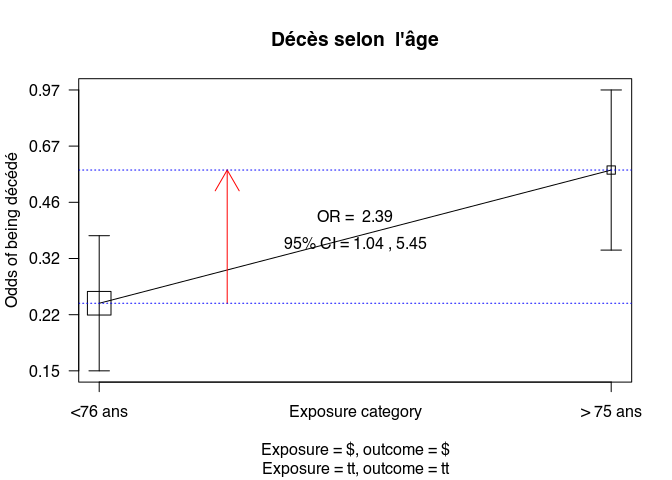

```
##
##         tt$age
## tt$deces <76 ans > 75 ans Total
##   vivant     101       28   129
##   décédé      24       16    40
##   Total      125       44   169
##
## OR =  2.4
## 95% CI =  1.13, 5.13
## Chi-squared = 5.31, 1 d.f., P value = 0.021
## Fisher's exact test (2-sided) P value = 0.038
```

#### CCMU

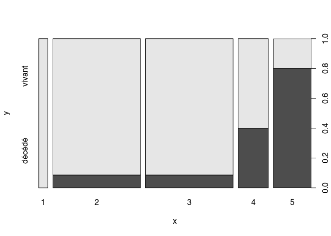

#### ASA initial

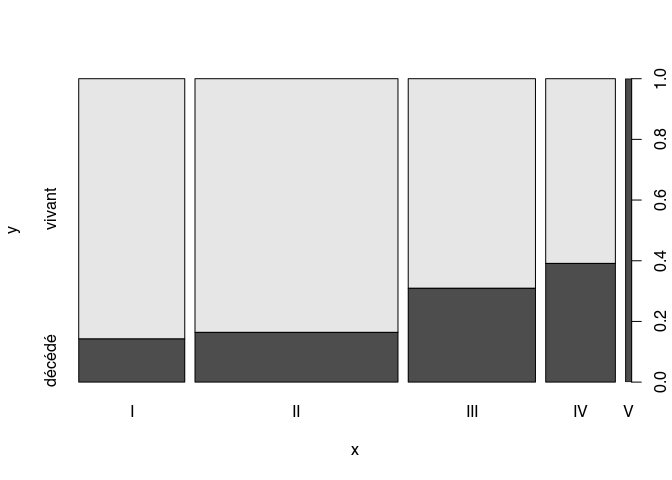

#### ADL initial

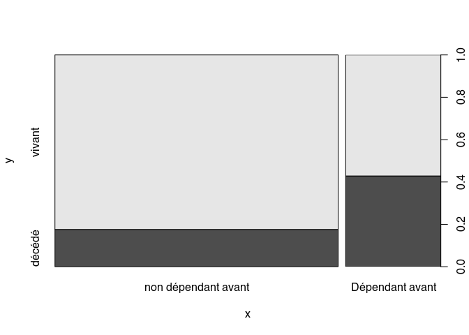

### Régression

On corrige sur l’état initial (ASA & CCMU).

Analyse multivariée

Dependent: deces

vivant

décédé

OR (univariable)

OR (multivariable)

age

<76 ans

101 (80.8)

24 (19.2)

> 75 ans

28 (63.6)

16 (36.4)

2.40 (1.12-5.13, p=0.023)

2.39 (0.74-7.96, p=0.146)

ccmu

1

6 (100.0)

0 (0.0)

2

53 (91.4)

5 (8.6)

3

53 (91.4)

5 (8.6)

4115871.26 (0.00-NA, p=0.992)

4

12 (60.0)

8 (40.0)

28363208.41 (0.00-NA, p=0.992)

24507795.79 (0.00-NA, p=0.991)

5

5 (20.0)

20 (80.0)

170179250.47 (0.00-NA, p=0.991)

480776354.85 (0.00-NA, p=0.989)

asa_initial

I

30 (85.7)

5 (14.3)

II

56 (83.6)

11 (16.4)

1.18 (0.39-4.03, p=0.779)

0.70 (0.12-3.95, p=0.676)

III

29 (69.0)

13 (31.0)

2.69 (0.89-9.26, p=0.092)

3.51 (0.65-23.25, p=0.161)

IV

14 (60.9)

9 (39.1)

3.86 (1.12-14.64, p=0.036)

6.22 (0.89-51.33, p=0.074)

V

0 (0.0)

2 (100.0)

34546877.16 (0.00-NA, p=0.987)

41583721.09 (0.00-NA, p=0.994)

[figure not shown]

# Critères secondaires

Tous les critères concernant l’évolution sur trois mois sont calculés uniquement sur les survivants soit 129 cas.

## Évolution du score ADL

ADL initial et à 3 mois

|  | non dépendant à 3 mois | Dépendant à 3 mois |
| --- | --- | --- |
| non dépendant avant | 96 (92.3%) | 8 (7.7%) |
| Dépendant avant | 0 (0%) | 24 (100%) |

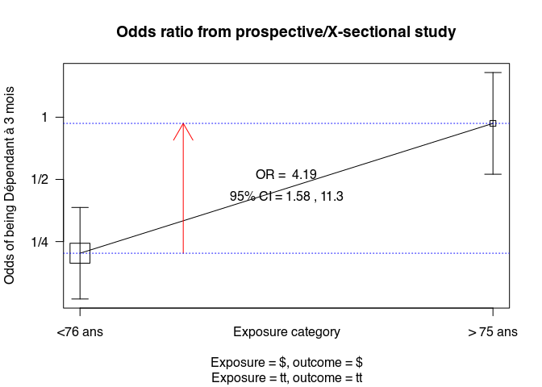

```
##
##                         tt$age
## tt$adl_3_mois            <76 ans > 75 ans Total
##   non dépendant à 3 mois      82       15    97
##   Dépendant à 3 mois          18       14    32
##   Total                      100       29   129
##
## OR =  4.25
## 95% CI =  1.75, 10.35
## Chi-squared = 11.05, 1 d.f., P value = 0.001
## Fisher's exact test (2-sided) P value = 0.003
```